# A problem in calculating pharmacokinetic parameters in MRGsolve

Author

Johannes Starp

# Introduction

The calculation of pharmacokinetic (PK) parameters can be achieved by incorporating code snippets into the model code using the R package “MRGsolve”, as outlined in the MRGsolve blog (Baron 2024b). The PK parameters of interest are:

- Area under the concentration time curve (AUC)
- Maximum concentration (c<sub>max</sub>)
- Time of maximum concentration (t<sub>max</sub>)

It was observed that there was a divergence between the concentration-time curve graph and the curve graph in the ascending part of the plot when the default simulation settings were utilised. Moreover, it has been determined that c<sub>max</sub> is not outputted correctly in certain settings. The resolution to this issue can be achieved through the adjustment of the solver settings. However, this is merely a workaround, as the user guide states that “hmax” should not be used regularly (Baron 2024a). The purpose of this document is twofold: firstly, to provide a detailed description of the problem; and secondly, to generate hypotheses on the causative factors of the problem.

# Methods

The scripts for reproducing the described problem can be accessed under https://github.com/JohannesStarp/mrgsolve_pk_parameters. The different simulations were adjusted by adjusting the solver settings.

```r
mod_run007_hmax <- update(mod_run007_default, hmax = 0.001)
```

Two different population pharmacokinetic models were used for the simulations. The two-compartment model used in the blog post and a one-compartment model written for this example were employed. The drug was administered as a 200 mg oral dose (first compartment) and as an infusion (first compartment) to the two-compartment and one-compartment models, respectively.

# Results

The results show the plots of the concentration in the central compartment vs. the predicted c<sub>max</sub>. The results are stratified for the two models and the solver settings.

## Default settings

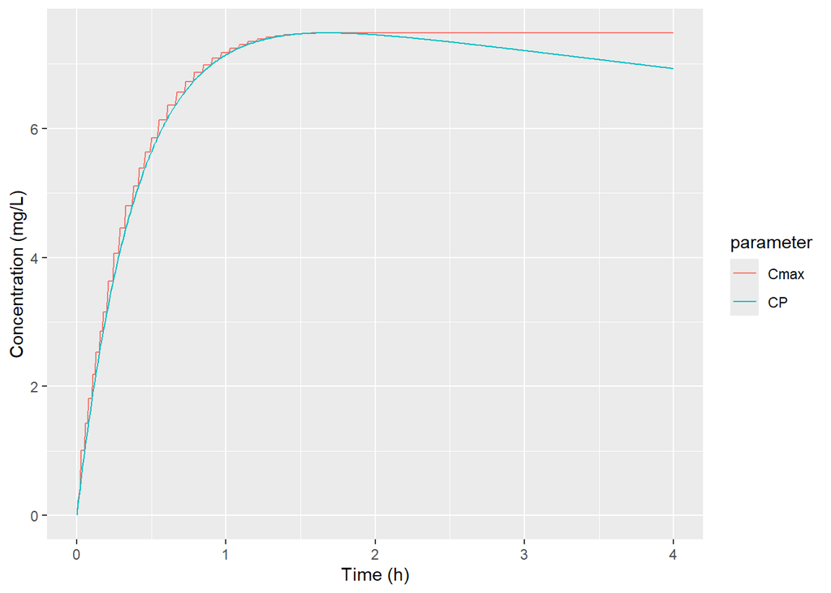

Plot of concentraion [mg/L] in the central compartment vs. prediction of maximum concentration [mg/L] for the two compartment model and oral administration of 200 mg. The solver settings were set to default.

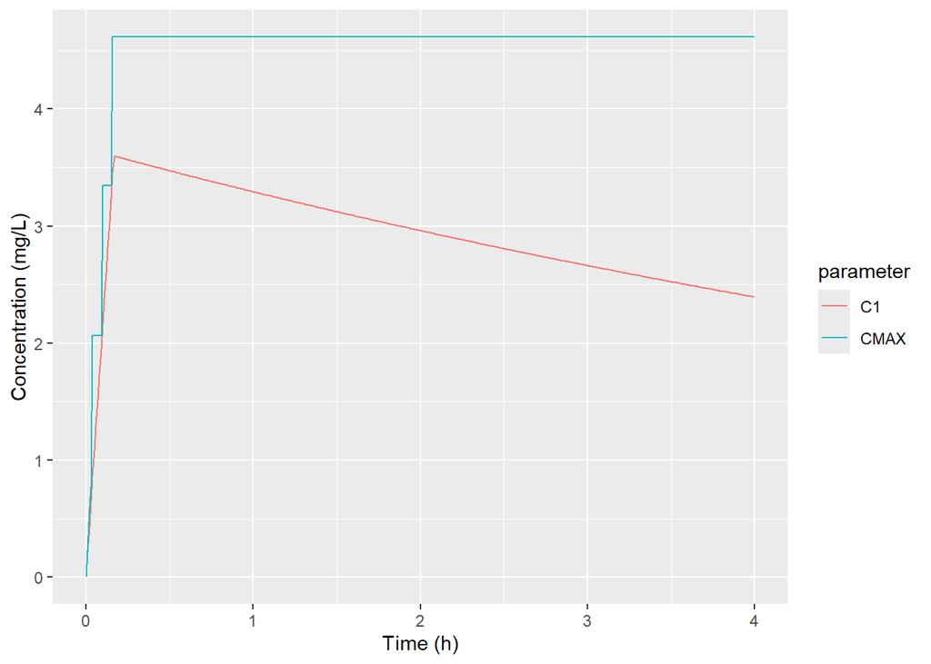

## Adjusted solver settings

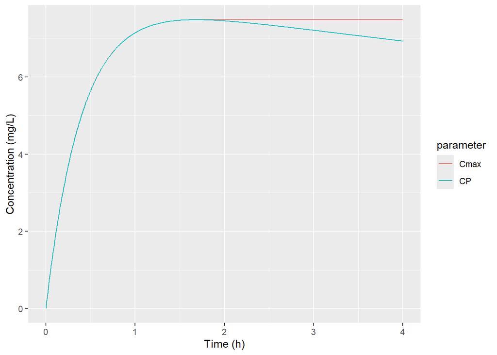

Plot of concentraion [mg/L] in the central compartment vs. prediction of maximum concentration [mg/L] for the two compartment model and oral administration of 200 mg. The solver settings were adapted using “hmax”.

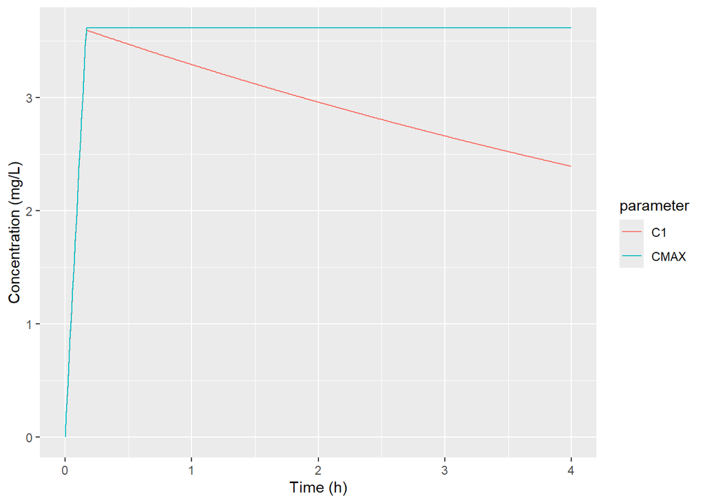

When the solver settings are adjusted by limiting ‘hmax’, both graphs show overlap in the ascending phase (absorption/infusion phase) and the C<sub>max</sub> is correctly predicted.

# Discussion

As the degree to which the concentration and c<sub>max</sub> curves deviate from each other appears to depend on the steepness of the concentration, and as the entire problem can be solved by adjusting the solver settings, the manner in which the ordinary differential equations (ODE) are solved during the simulation could explain the phenomenon. When adjusting the step size for the ODE solver, it is likely that higher concentrations are used in the $DES block, which are then saved as C<sub>max</sub> and are not readjusted when a finer step size is used to calculate the concentrations in the central compartment.

Further work could therefore focus on implementing the calculation of C<sub>max</sub> and T<sub>max</sub> using MRGsolve without adjusting the solver settings, as this could lead to increased run times.

## References

Baron, Kyle. 2024a. “Mrgsolve User Guide.” https://mrgsolve.org/user-guide/.

———. 2024b. “Simulate True Cmax with ODE.” https://mrgsolve.org/blog/posts/true-cmax.html.